# ISLR - Partial Answers

Joshua Malina

September 18, 2015

Chapter 3 – Applied Problems

Problem 8 (a) Use the lm() function to perform a simple linear regression with mpg as the response and horsepower as the predictor. Use the summary() function to print the results.

```r
lmodel <- lm(mpg ~ horsepower, data=Auto)
summary(lmodel)
```

```
##
## Call:
## lm(formula = mpg ~ horsepower, data = Auto)
##
## Residuals:
##      Min       1Q   Median       3Q      Max
## -13.5710  -3.2592  -0.3435   2.7630  16.9240
##
## Coefficients:
##              Estimate Std. Error t value Pr(>|t|)
## (Intercept) 39.935861   0.717499   55.66   <2e-16 ***
## horsepower  -0.157845   0.006446  -24.49   <2e-16 ***
## ---
## Signif. codes:  0 '***' 0.001 '**' 0.01 '*' 0.05 '.' 0.1 ' ' 1
##
## Residual standard error: 4.906 on 390 degrees of freedom
## Multiple R-squared:  0.6059, Adjusted R-squared:  0.6049
## F-statistic: 599.7 on 1 and 390 DF,  p-value: < 2.2e-16
```

1. Is there a relationship between the predictor and the re- sponse?

Yes, the p-value for horsepower is very low (<2e-16). And since the coefficient is less than zero (-0.15), we can say that the relationship between predictor (horsepower) and response (mpg) is negative.

2. How strong is the relationship between the predictor and the response?

3. Is the relationship between the predictor and the response positive or negative?

The relationship is negative.

4. What is the predicted mpg associated with a horsepower of 98? What are the associated 95 % confidence and prediction intervals?

MPG when horsepower=98

```r
h <- data.frame(horsepower=98)
predict(lmodel, h)
```

```
##        1
## 24.46708
```

Confidence interval, 95%:

```r
predict(lmodel, h, interval="confidence")[1, 2:3]
```

```
##      lwr      upr
## 23.97308 24.96108
```

Prediction interval, 95%

```r
predict(lmodel, h, interval="predict")[1, 2:3]
```

```
##      lwr      upr
## 14.80940 34.12476
```

2. Plot the response and the predictor. Use the abline() function to display the least squares regression line.

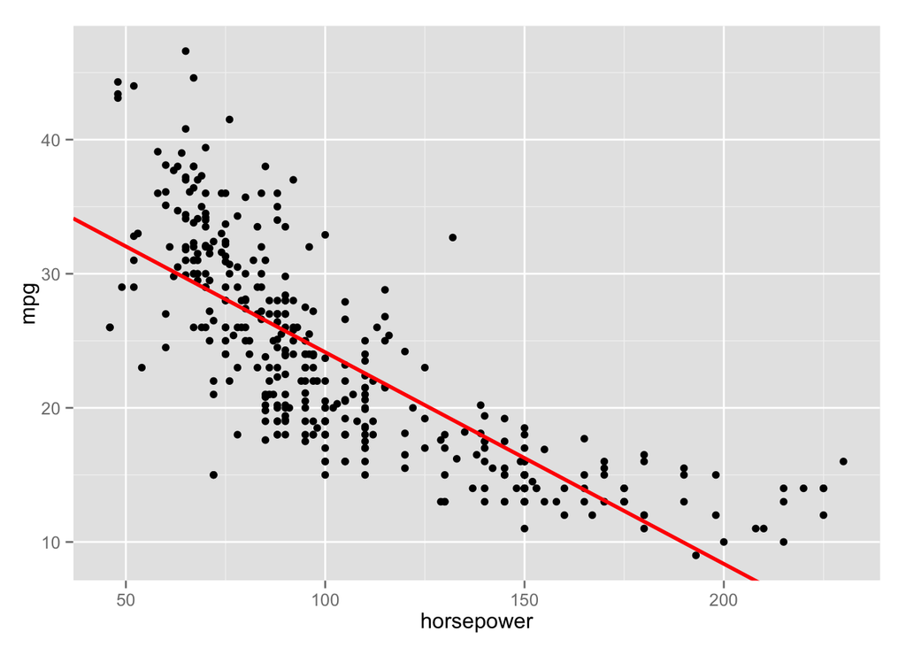

```r
c = coef(lmodel)
ggplot(data=Auto, aes(horsepower, mpg)) + geom_point() + geom_abline(aes(intercept=c[1], slope=c[2]), color="red", size=1)
```

3. Use the plot() function to produce diagnostic plots of the least squares regression fit. Comment on any problems you see with the fit.

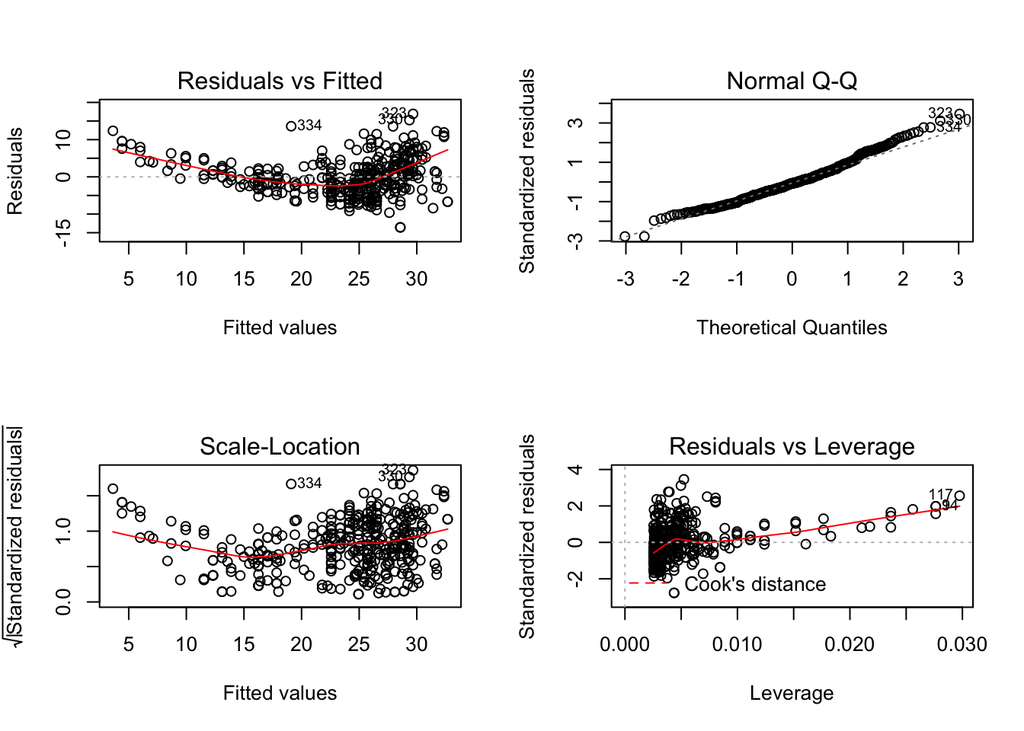

```r
par(mfrow=c(2,2))
plot(lmodel)
```

It looks like there is some non-linear trend that is not captured in the model, as per the residual vs fitted plot. In the residuals vs leverage plot, it seems that there may be a few points that have high leverage.